# Análisis Exploratorio

Sergio Martí

2023-03-20

# Análisis Exploratorio

Se parten de cuatro archivos distintos que analizar: datos clínicos, datos del sistema inmunológico, datos del análisis digital del tumor y datos procedentes de cuantificación de RNA-seq. Para cada achivo se debe de responder a las siguientes preguntas:

- Número de predictores.
- Número de muestras.
- Tipo de identificador correspondiente al paciente.
- Cantidad de pacientes con datos disponibles en las cuatro fuentes de datos.

## Datos clínicos.

Los datos clínicos se encuentra en formato “csv” (coma separeted values) dentro del archivo llamado “Main.csv”. Para leer estos datos en R se utilizará la función `read.csv()`. Esta función sirve para leer este tipo de archivos, y los carga en memoria como un dataframe.

```r
# Lemos los datos clínicos
dfClinical <- read.csv("./datos/Main.csv")

# Visualizar el dataframe
# View(dfClinical)
```

### Número de predictores y número de muestras.

El número de muestras se puede obtener contando el número de registros:

```r
# Número de registros
nrow(dfClinical)
```

```
## [1] 147
```

El número de predictores se pude calcular a partir del número de variables del dataframe:

```r
# Número de columnas
ncol(dfClinical)
```

```
## [1] 74
```

A partir de aquí hay que descontar las variables que no se pueden utilizar como predictores. Las variables “**X**” y “**Trial.ID**” son los identificadores de los pacientes. Destacar que hay cinco variables que aportan información sobre la respuesta del tratamiento. La variable “**resp.pCR**” determina si la paciente ha respondido de forma satisfactoria al nuevo tratamiento o no. Se ha indicado que las variables: “**resp.Chemosensitive**”, “**resp.Chemoresistant**”, “**RCB.score**” y “**RCB.category**” son redundantes con la primera. Más adelante se explica mejor a que hacen referencia cada una.

```r
# Las 8 primeras columnas son los ids de los pacientes y variables de respuesta al tratamiento
ncol(dfClinical[,8:ncol(dfClinical)])
```

```
## [1] 67
```

Descontando las variables anteriores, hay 67 variables clínicas que se pueden utilizar como predictores.

### Valores nulos.

Para calcular el número de nulos, se puede utilizar la función `is.na()`. Esta función devuleve verdadero o falso si un vector contiene valores nulos. La función `sum()` suma todos los valores de un vector. Utilizando ambas funciones se puede determinar si las variables del dataframe contienen nulos.

```r
# Encontrar si hay algún dato "Not Available"
sum(is.na(dfClinical[,3:ncol(dfClinical)])) > 1
```

```
## [1] FALSE
```

```r
# Encontrar si hay algún dato nulo
sum(is.null(dfClinical[,3:ncol(dfClinical)])) > 1
```

```
## [1] FALSE
```

No hay ningún registro que sea “Not Available” (NA) o nulo (NULL) en las variables clínicas.

Si hubiera algún dato nulo o not available, dependiendo de la naturaleza de los datos se podrían tomar diferentes estratégias para resolver el problema: una opción es decidir no trabajar con los registros que contienen nulos. Es una buena opción si se tiene una muestra muy grande, pero se tiene que tener en cuenta que se pierde información al realiar esta selección. Otra opción es asignar el valor promedio de la variable a los registros con datos nulos o not available. Si la variable es de tipo categórica/cualitativa, se puede asignar el valor que más se repite. Si la variable es cuantitativa, se puede asignar el valor estadístico de la media o la moda.

### Número de variables numéricas y variables categóricas.

Previamente a realizar un análisis, es necesario comprobar la naturaleza de estos datos. Utilizando la función `str()` se puede obtener esta información.

```r
# Comprobamos la naturaleza de las variables
str(dfClinical)
```

```
## 'data.frame':    147 obs. of  74 variables:
##  $ X                         : int  0 1 2 3 4 5 6 7 8 9 ...
##  $ Trial.ID                  : chr  "T001" "T002" "T003" "T004" ...
##  $ resp.pCR                  : int  0 1 1 0 0 0 0 0 0 0 ...
##  $ resp.Chemosensitive       : int  1 1 1 0 0 0 1 0 1 0 ...
##  $ resp.Chemoresistant       : int  0 0 0 0 0 1 0 0 0 0 ...
##  $ RCB.score                 : num  0.98 0 0 2.08 2.87 ...
##  $ RCB.category              : int  1 0 0 2 2 3 1 2 1 2 ...
##  $ Age.at.diagnosis          : int  51 42 36 33 49 46 42 50 53 56 ...
##  $ Histology                 : int  1 1 1 1 1 1 1 1 1 1 ...
##  $ ER.status                 : int  1 1 1 1 1 1 1 -1 1 1 ...
##  $ HER2.status               : int  1 -1 1 -1 -1 -1 1 -1 1 1 ...
##  $ LN.at.diagnosis           : int  -1 1 -1 -1 1 1 -1 1 1 -1 ...
##  $ Grade.pre.chemotherapy    : int  3 2 2 3 3 3 2 3 2 2 ...
##  $ Size.at.diagnosis         : int  21 98 26 51 72 22 32 57 48 25 ...
```

[output cut: 60 more lines]

Con este resultado, se puede comprobar el tipo de las variables presentes en el dataframe. No es necesaria ninguna reorganización del dataframe porque las variables se encuentran en las columnas y los datos de los pacientes se encuentran en las filas o registros.

A cotinuación, se va a proceder a separar las variables cuantitativas de las variables cualitativas presentes en el dataframe. Ya que los dos tipos de variables requiren tratarse de forma distinta.

```r
# Comprobamos que todas las variables son numericas
sum(is.numeric(dfClinical[,3:ncol(dfClinical)])) > 1
```

```
## [1] FALSE
```

```r
# Seleccionamos solamente las variables que se pueden utilizar como predictores
dfClinicalVars <- dfClinical[,3:ncol(dfClinical)]

# Por si acaso hay alguna variable numerica que en realidad sea un factor, se utiliza la función unique()
vColIsFactor <- sapply(dfClinicalVars, function(v) {
  return(!(length(unique(v)) > 4))
})

# Seleccionamos las variables que son factores
dfFacVars <- dfClinicalVars[vColIsFactor]

# Las variables que no son factores son numericas
dfNumVars <- dfClinicalVars[!vColIsFactor]

# Guardamos en un vector boleano si la variable es tipo integer
vColsInt <- sapply(dfNumVars, is.integer)

# Seleccionamos las columnas de datos enteros
dfIntVars <- dfNumVars[vColsInt]

# Filtramos las variables que no son numeros enteros
dfNumVars <- dfNumVars[!vColsInt]

# ----------------------------------------------------------------------

# Mostramos el número de variables de cada tipo
sprintf("Número de variables numéricas cuantitativas: %d", length(dfNumVars))
```

```
## [1] "Número de variables numéricas cuantitativas: 43"
```

```r
sprintf("Número de variables enteras cuantitativas: %d", length(dfIntVars))
```

```
## [1] "Número de variables enteras cuantitativas: 11"
```

```r
sprintf("Número de variables categóricas: %d", length(dfFacVars))
```

```
## [1] "Número de variables categóricas: 18"
```

```r
# ----------------------------------------------------------------------

# Transformamos a factores las variables cualitativas
dfFacVars[, 1:ncol(dfFacVars)] <-
  # TODO esto no funciona, preguntar al papa
  lapply(dfFacVars[, 1:ncol(dfFacVars)], function(x) {
    myFactor <- factor(x)

    # RCB.category
    if (length(levels(myFactor)) == 4) {
      levels(myFactor) <- c("pCR", "RCB-I", "RCB-II", "RCB-III")
    }

    # Todos los factores con dos niveles
    if (length(levels(myFactor)) == 2) {

      # Grade.pre.chemotherapy
      if (sum(levels(myFactor) != c("2", "3")) > 1) {

        # ER.status, HER2.status & LN.at.diagnosis
        if (!(sum(levels(myFactor) != c("-1", "1")) > 1)) {
          x <- replace(x, x == -1, 0)
        }

        myFactor <- as.logical(x)

      }
    }

    return(myFactor)

  })

# Mostramos las variables
str(dfIntVars)
```

```
## 'data.frame':    147 obs. of  11 variables:
##  $ Age.at.diagnosis : int  51 42 36 33 49 46 42 50 53 56 ...
##  $ Size.at.diagnosis: int  21 98 26 51 72 22 32 57 48 25 ...
##  $ ER.Allred        : int  8 7 8 4 8 7 6 0 8 8 ...
##  $ All.TMB          : int  170 146 97 124 116 24 32 26 308 105 ...
##  $ Coding.TMB       : int  92 74 43 62 57 18 18 16 167 57 ...
##  $ Expressed.NAg    : int  88 28 24 35 6 13 12 1 145 13 ...
##  $ HRD.LOH          : int  4 16 8 11 10 2 11 8 8 6 ...
##  $ HRD.TelomericAI  : int  13 22 14 22 15 2 8 9 15 19 ...
##  $ HRD.LST          : int  3 25 2 6 3 0 0 0 1 1 ...
##  $ HRD.sum          : int  20 63 24 39 28 4 19 17 24 26 ...
##  $ Chemo.NumCycles  : int  6 6 6 6 6 6 6 6 6 6 ...
```

```r
str(dfFacVars)
```

```
## 'data.frame':    147 obs. of  18 variables:
##  $ resp.pCR                  : logi  FALSE TRUE TRUE FALSE FALSE FALSE ...
##  $ resp.Chemosensitive       : logi  TRUE TRUE TRUE FALSE FALSE FALSE ...
##  $ resp.Chemoresistant       : logi  FALSE FALSE FALSE FALSE FALSE TRUE ...
##  $ RCB.category              : Factor w/ 4 levels "pCR","RCB-I",..: 2 1 1 3 3 4 2 3 2 3 ...
##  $ Histology                 : logi  TRUE TRUE TRUE TRUE TRUE TRUE ...
##  $ ER.status                 : logi  TRUE TRUE TRUE TRUE TRUE TRUE ...
##  $ HER2.status               : logi  TRUE FALSE TRUE FALSE FALSE FALSE ...
##  $ LN.at.diagnosis           : logi  FALSE TRUE FALSE FALSE TRUE TRUE ...
##  $ Grade.pre.chemotherapy    : Factor w/ 2 levels "2","3": 2 1 1 2 2 2 1 2 1 1 ...
##  $ CodingMuts.PIK3CA         : logi  FALSE FALSE FALSE FALSE FALSE TRUE ...
##  $ CodingMuts.TP53           : logi  TRUE FALSE FALSE TRUE TRUE FALSE ...
##  $ HLA.LOH                   : logi  FALSE FALSE FALSE TRUE FALSE FALSE ...
##  $ Chemo.first.Taxane        : logi  FALSE TRUE FALSE FALSE FALSE TRUE ...
##  $ Chemo.first.Anthracycline : logi  TRUE FALSE TRUE TRUE TRUE FALSE ...
##  $ Chemo.second.Taxane       : logi  TRUE FALSE TRUE TRUE TRUE FALSE ...
##  $ Chemo.second.Anthracycline: logi  FALSE TRUE FALSE FALSE FALSE TRUE ...
##  $ Chemo.any.Anthracycline   : logi  TRUE TRUE TRUE TRUE TRUE TRUE ...
##  $ Chemo.any.antiHER2        : logi  TRUE FALSE TRUE FALSE FALSE FALSE ...
```

```r
# summary(dfFacVars)

# ----------------------------------------------------------------------

# Construimos un nuevo dataframe, reescribiendo el anterior, con los datos clínicos, ahora que cada variable tiene su tipo correcto (numerico, entero, logico o factor)
dfClinical <- cbind(
  X = dfClinical$X,
  Trial.ID = dfClinical$Trial.ID,
  dfFacVars,
  dfIntVars,
  dfNumVars)

# ----------------------------------------------------------------------

# Se puede eliminar las variables que ya no son necesarias
rm(dfNumVars, dfIntVars, vColsInt, vColIsFactor, dfClinicalVars)
```

Para mostrar la información de las variables categóricas, se va a utilizar la función `describe()` del paquete `Hmisc` porque muestra genera una salida más detallada y comprensible.

```r
library(Hmisc) # <- función `describe()`
library(tidyverse) # <- necesario para reorganizar dataframes y usar tuberias
# La función describe del paquete Hmisc muestra un output más comprensible que la función summary
html(describe(dfFacVars))
```

dfFacVars  
18 Variables 147 Observations

resp.pCR

| n | missing | distinct |
| --- | --- | --- |
| 147 | 0 | 2 |

```
 Value      FALSE  TRUE
 Frequency    109    38
 Proportion 0.741 0.259
```

resp.Chemosensitive

| n | missing | distinct |
| --- | --- | --- |
| 147 | 0 | 2 |

```
 Value      FALSE  TRUE
 Frequency     86    61
 Proportion 0.585 0.415
```

resp.Chemoresistant

| n | missing | distinct |
| --- | --- | --- |
| 147 | 0 | 2 |

```
 Value      FALSE  TRUE
 Frequency    122    25
 Proportion  0.83  0.17
```

RCB.category

| n | missing | distinct |
| --- | --- | --- |
| 147 | 0 | 4 |

```
 Value          pCR   RCB-I  RCB-II RCB-III
 Frequency       38      23      61      25
 Proportion   0.259   0.156   0.415   0.170
```

Histology

| n | missing | distinct |
| --- | --- | --- |
| 147 | 0 | 2 |

```
 Value      FALSE  TRUE
 Frequency     16   131
 Proportion 0.109 0.891
```

ER.status

| n | missing | distinct |
| --- | --- | --- |
| 147 | 0 | 2 |

```
 Value      FALSE  TRUE
 Frequency     50    97
 Proportion  0.34  0.66
```

HER2.status

| n | missing | distinct |
| --- | --- | --- |
| 147 | 0 | 2 |

```
 Value      FALSE  TRUE
 Frequency     92    55
 Proportion 0.626 0.374
```

LN.at.diagnosis

| n | missing | distinct |
| --- | --- | --- |
| 147 | 0 | 2 |

```
 Value      FALSE  TRUE
 Frequency     70    77
 Proportion 0.476 0.524
```

Grade.pre.chemotherapy

| n | missing | distinct |
| --- | --- | --- |
| 147 | 0 | 2 |

```
 Value          2     3
 Frequency     57    90
 Proportion 0.388 0.612
```

CodingMuts.PIK3CA

| n | missing | distinct |
| --- | --- | --- |
| 147 | 0 | 2 |

```
 Value      FALSE  TRUE
 Frequency    109    38
 Proportion 0.741 0.259
```

CodingMuts.TP53

| n | missing | distinct |
| --- | --- | --- |
| 147 | 0 | 2 |

```
 Value      FALSE  TRUE
 Frequency     62    85
 Proportion 0.422 0.578
```

HLA.LOH

| n | missing | distinct |
| --- | --- | --- |
| 147 | 0 | 2 |

```
 Value      FALSE  TRUE
 Frequency    121    26
 Proportion 0.823 0.177
```

Chemo.first.Taxane

| n | missing | distinct |
| --- | --- | --- |
| 147 | 0 | 2 |

```
 Value      FALSE  TRUE
 Frequency     56    91
 Proportion 0.381 0.619
```

Chemo.first.Anthracycline

| n | missing | distinct |
| --- | --- | --- |
| 147 | 0 | 2 |

```
 Value      FALSE  TRUE
 Frequency     91    56
 Proportion 0.619 0.381
```

Chemo.second.Taxane

| n | missing | distinct |
| --- | --- | --- |
| 147 | 0 | 2 |

```
 Value      FALSE  TRUE
 Frequency     91    56
 Proportion 0.619 0.381
```

Chemo.second.Anthracycline

| n | missing | distinct |
| --- | --- | --- |
| 147 | 0 | 2 |

```
 Value      FALSE  TRUE
 Frequency     68    79
 Proportion 0.463 0.537
```

Chemo.any.Anthracycline

| n | missing | distinct |
| --- | --- | --- |
| 147 | 0 | 2 |

```
 Value      FALSE  TRUE
 Frequency     12   135
 Proportion 0.082 0.918
```

Chemo.any.antiHER2

| n | missing | distinct |
| --- | --- | --- |
| 147 | 0 | 2 |

```
 Value      FALSE  TRUE
 Frequency     91    56
 Proportion 0.619 0.381
```

- “**Grade.pre.chemotherapy**”: toma valores de 2 o 3.
- “**RCB.category**”: indica la clasificación “*residual cancer burden*”, presenta cuatro niveles, pCR, RCB-I, RCB-II y RCB-III.

En las variables enteras, cabe destacar dos variables:

- “**ER.Allred**”: corresponde con la puntuación “*Allred*” para la evaluación de receptores de estrógenos y progesterona. Toma valores de 0 a 8, siendo valores discretos. Las puntuaciones de 0 a 2 se consideran negativas y las puntuaciones de 3-8 se consideran positivas. Estos valores coinciden con la variable lógica “**ER.status**”.
- “**Chemo.NumCycles**”: corresponde con el número de ciclos de quimioterapia que ha recibido la paciente. En esta muestra, las pacientes recibieron 2, 4, 5, 6 o 7 ciclos de quimioterapia.

Estas dos variables numericas de tipo entero no deberían de analizarse con las demás variables cuantitativas, ya que su rango de valores es pequeño. Se podría trabajar con ellas como si fuesen factores, pero no vale la pena.

## Variables que miden la respuesta al tratamiento.

Como se ha comentado anteriormente, las variables más importantes son las que aportan información sobre la respuesta del tratamiento. Estas son: “**resp.pCR**”, “**resp.Chemosensitive**”, “**resp.Chemoresistant**”, “**RCB.score**” y “**RCB.category**”.

Durante la cirugía, a cada paciente, se evaluó la respuesta a dicho tratamiento utilizando la clasificación de “**carga de cáncer residual**”, en inglés “*Residual Cancer Burden*”, llamado por sus siglas: **RCB**.

Estas variables son redudantes entre si. Se dan los siguientes casos:

- La variable “**resp.pCR**” coincide con los mismos datos que la variable “**RCB.category**”, ya que las pacientes que han respondido de forma completa al tratamiento (según la clasificación, los casos pCR) son los registros positivos de “**resp.pCR**”.
- Las pacientes con tumores resistentes a la quimioterapia, “**resp.Chemoresistant**” se clasifican como “RCB-III” en el factor “**RCB.category**”, el caso con peor respuesta al tratamiento.
- Las pacientes con tumores sensibles a la quimioterapia, “**resp.Chemosensitive**” son pacientes clasificadas como “pCR” y “RCB-I” en el factor “**RCB.category**”, los dos casos con mejor respuesta al tratamiento.
- La variable “**RCB.score**”, que es numérica y cuantitativa, es la puntuación asignada a cada paciente según la clasificación RCB. Por lo tanto, es redundánte con la variable “**RCB.category**” ya que es la misma información pero discretizada (convertida a niveles).

```r
# Las pacientes resistentes a la quimioterapia son las mismas clasificadas como RCB-III.
lPatientsChemoresistant <- dfClinical[dfClinical$resp.Chemoresistant == TRUE,]$Trial.ID
lPatientsChemoresistant
```

```
##  [1] "T006" "T016" "T025" "T043" "T044" "T050" "T058" "T061" "T065" "T068"
## [11] "T096" "T109" "T115" "T116" "T127" "T131" "T140" "T145" "T150" "T156"
## [21] "T159" "T161" "T174" "T176" "T178"
```

```r
lPatientsRCB3 <- dfClinical[dfClinical$RCB.category == "RCB-III",]$Trial.ID
lPatientsRCB3
```

```
##  [1] "T006" "T016" "T025" "T043" "T044" "T050" "T058" "T061" "T065" "T068"
## [11] "T096" "T109" "T115" "T116" "T127" "T131" "T140" "T145" "T150" "T156"
## [21] "T159" "T161" "T174" "T176" "T178"
```

```r
bAreEqual <- sum(lPatientsChemoresistant == lPatientsRCB3) > 1
sprintf("¿Las pacientes resistentes a la quimioterapia están clasficadas como RCB-III?: %s", ifelse(bAreEqual, "sí", "no"))
```

```
## [1] "¿Las pacientes resistentes a la quimioterapia están clasficadas como RCB-III?: sí"
```

```r
rm(lPatientsChemoresistant, lPatientsRCB3, bAreEqual)

# Las pacientes con tumores sensibles a la quimioterapia están clasificadas en pCR o RCB-I
unique(dfClinical[dfClinical$resp.Chemosensitive == TRUE,]$RCB.category)
```

```
## [1] RCB-I pCR
## Levels: pCR RCB-I RCB-II RCB-III
```

```r
unique(dfClinical[dfClinical$resp.Chemosensitive == FALSE,]$RCB.category)
```

```
## [1] RCB-II  RCB-III
## Levels: pCR RCB-I RCB-II RCB-III
```

Ahora, se va a proceder a gráficar las variables, con el fin de mostrar mejor su distribución:

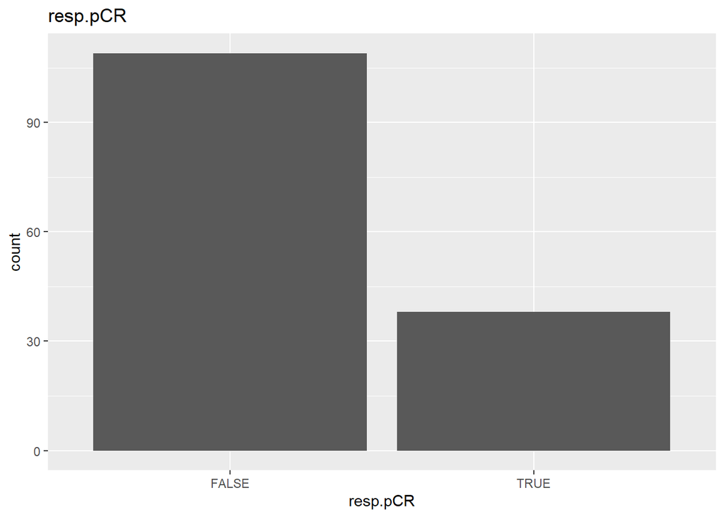

```r
ggplot2::ggplot(dfClinical, aes(x = resp.pCR)) +
  ggplot2::geom_bar() +
  ggplot2::ggtitle("resp.pCR")
```

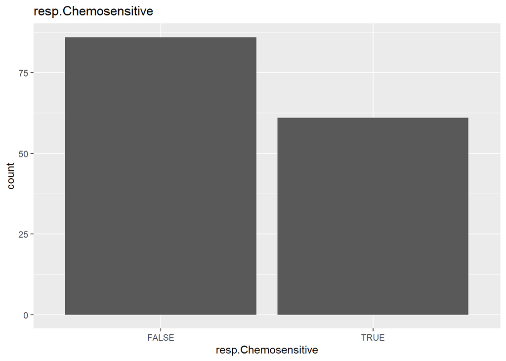

```r
# resp.Chemosensitive
ggplot2::ggplot(dfClinical, aes(x = resp.Chemosensitive)) +
  ggplot2::geom_bar() +
  ggplot2::ggtitle("resp.Chemosensitive")
```

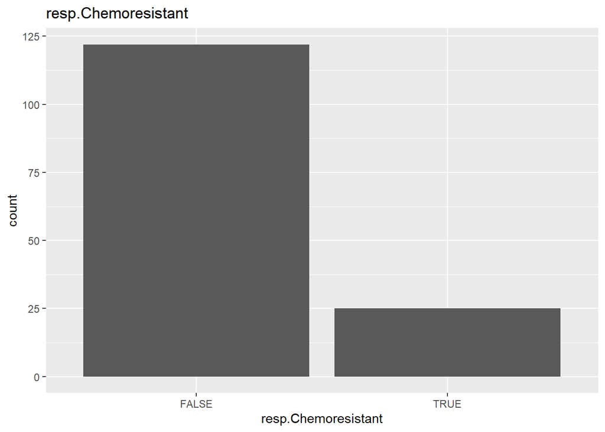

```r
# resp.Chemoresistant
ggplot2::ggplot(dfClinical, aes(x = resp.Chemoresistant)) +
  ggplot2::geom_bar() +
  ggplot2::ggtitle("resp.Chemoresistant")
```

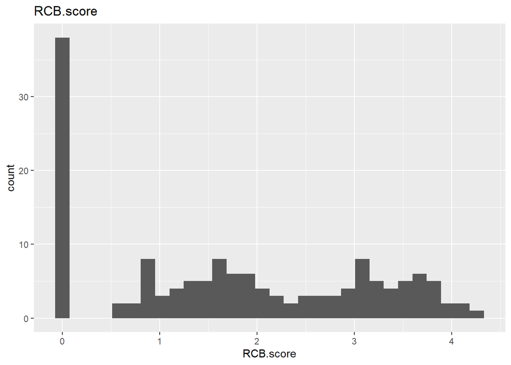

```r
# RCB.score
ggplot2::ggplot(dfClinical, aes(x = RCB.score)) +
  ggplot2::geom_histogram() +
  ggplot2::ggtitle("RCB.score")
```

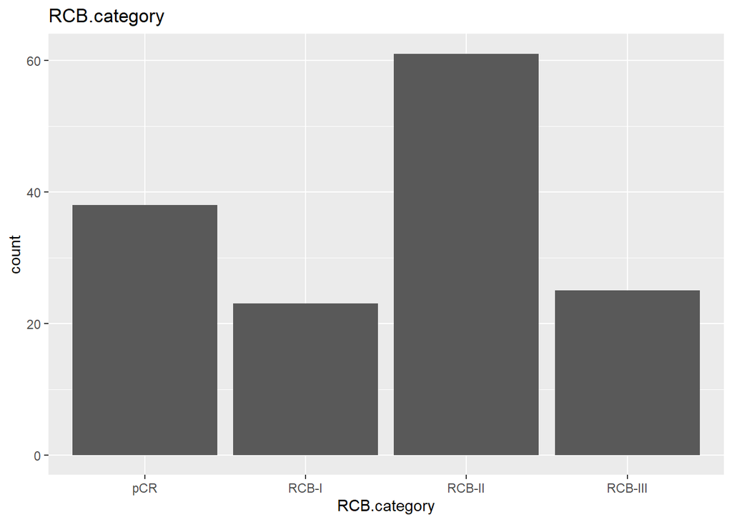

```r
# RCB.category
ggplot2::ggplot(dfClinical, aes(x = RCB.category)) +
  ggplot2::geom_bar() +
  ggplot2::ggtitle("RCB.category")
```

Posteriormente, se van a realizar análisis de correlación para las variables clínicas y modelos de regresión logística para predecir la variable “**resp.pCR**”.

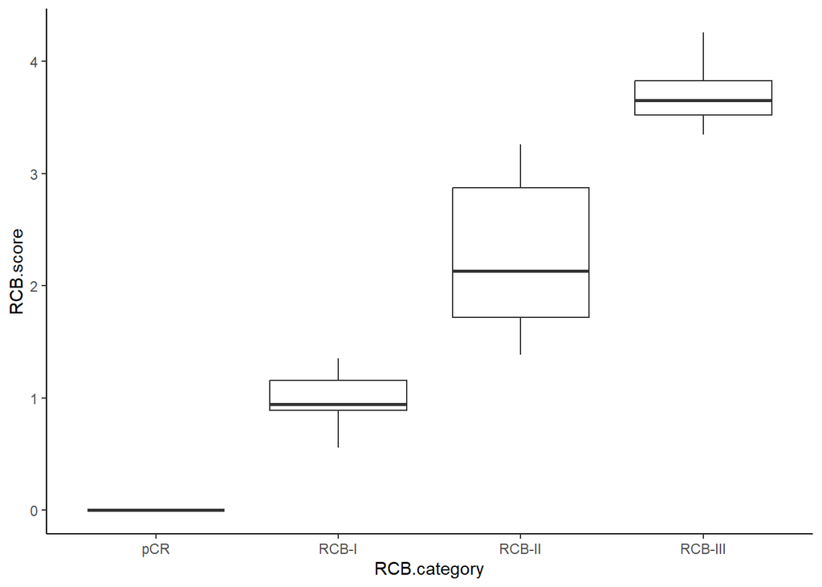

```r
ggplot2::ggplot(dfClinical, aes(x = RCB.category, y = RCB.score)) +
  ggplot2::geom_boxplot() +
  ggplot2::theme_classic()
```

## Guardar archivos RDS

```r
saveRDS(dfClinical, file = "dfClinical.RDS")
```